# Modelos de clasificación

- **Víctor Bucheli Guerrero**
- **Universidad del Valle**
- **Mayo 24 / 2018**

En las regresiones lineales:

- La información es modelada para ajustarse a una función de la forma mx+b
- Usualmente usa el método del mínimo cuadrado para el ajuste.
- el modelo es usado para predecir.

### Cargando los datos

El dataset consta de 88 tuplas y de 4 atributos: * Nombre: Nombre del carro * CaballosFuerza: indica los caballos de fuerza del carro * Precio: Precio del carro * Familiar: Variable que indica si el carro es familiar o no (1 familiar, 0 no familiar)

```r
#Cargamos el dataset
carros.dataset = read.csv("pricevshp.csv")

# Asignamos los nombres de las columnas
colnames(carros.dataset) <- c("Nombre","CaballosFuerza","Precio","Familiar")

carros.dataset
```

| Nombre | CaballosFuerza | Precio | Familiar |
| --- | --- | --- | --- |
| Merc 240D | 62 | 11900 | 1 |
| Ford Festiva 4 | 63 | 6319 | 1 |
| Toyota Corolla | 65 | 17872 | 1 |
| Fiat 128 | 66 | 3470 | 1 |
| Fiat X1-9 | 66 | 9640 | 1 |
| Subaru Justy 3 | 73 | 5866 | 1 |
| Pontiac LeMans 4 | 74 | 7254 | 1 |
| Toyota Tercel 4 | 78 | 6488 | 1 |
| Mercury Tracer 4 | 82 | 8672 | 1 |
| Ford Escort 4 | 90 | 7402 | 1 |

[output cut: 78 more lines]

### Graficando los datos

Cada vehículo representa un punto (xi, yi), en donde el eje *X* representa los caballos de fuerza que tiene el vehiculo y el eje *y* muestra si el carro es familiar o no (1 o 0 respectivamente). Pintamos la grafica diferenciando cada vehiculo por categoría (familiar, no familiar):

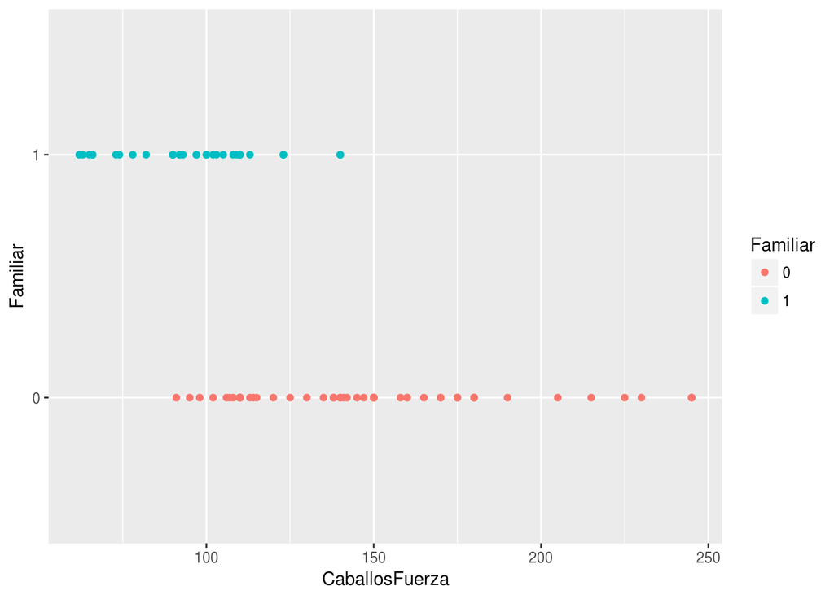

```r
require(ggplot2)
aux <- carros.dataset # Creamos una copia para cambiar el atributo Familiar a dato categórico y poder graficar
aux[, "Familiar"] <- as.factor(aux[, "Familiar"])
qplot(CaballosFuerza, Familiar, data = aux, colour = Familiar)
```

### Diagrama de cajas y bigotes

Mediante el diagrama de cajas y bigotes observamos los valores atípicos que pueden traer malos resultados.

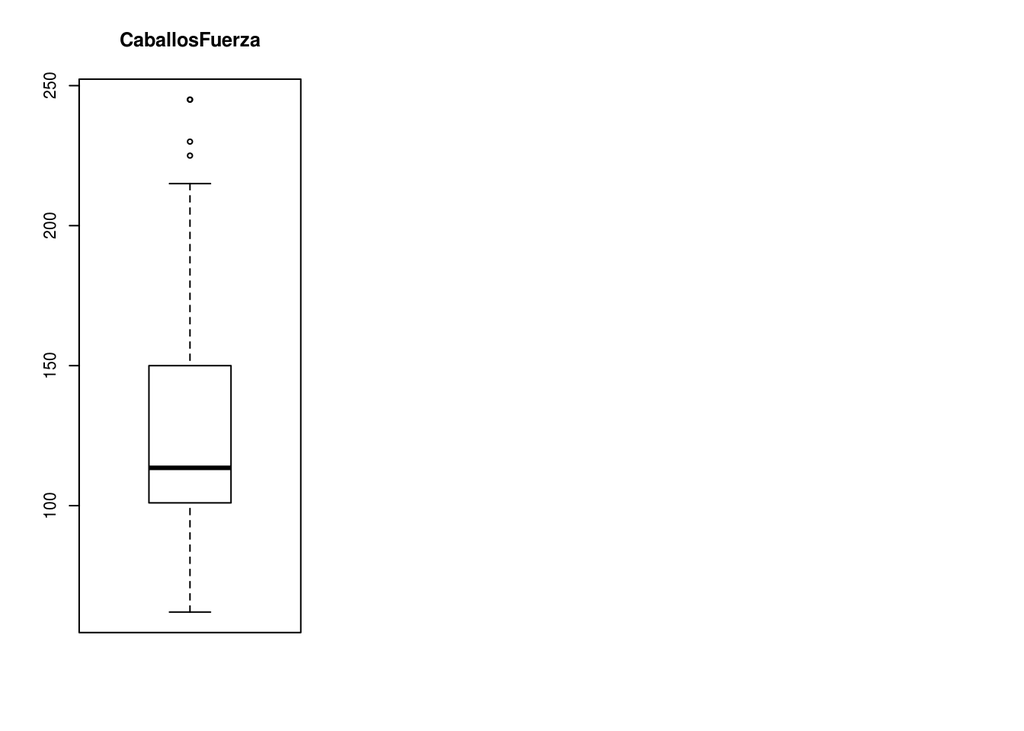

```r
par(mfrow=c(1, 3))#Obtenemos las tres gráficas  en el mismo cuadro de respuesta.
boxplot(carros.dataset[, "CaballosFuerza"], main="CaballosFuerza")  #Diagrama para "CaballosFuerza"
#boxplot(carros.dataset[, "Precio"], main="Precio")  #Diagrama para el "Precio""
```

### Diagramas de densidad e histograma

El diagrama de densidad nos permite determinar si la distribución de cada una de las variables involucradas es normal.

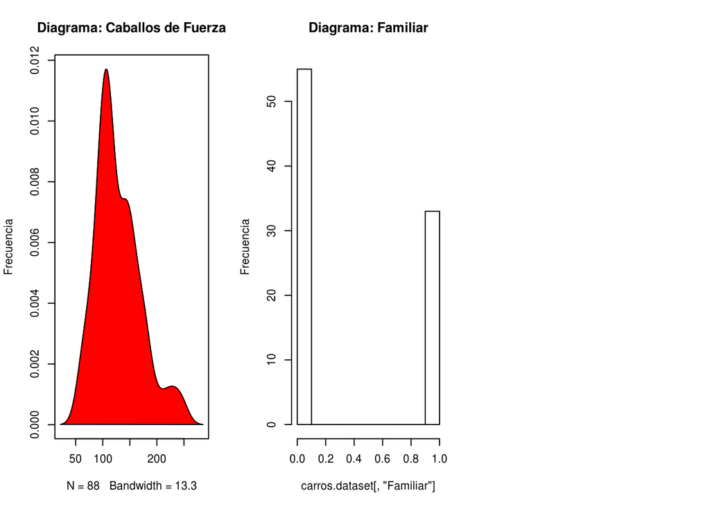

```r
#install.packages('e1071', dep = TRUE)
library(e1071)
par(mfrow=c(1, 3))#Obtenemos las dos gráficas  en el mismo cuadro de respuesta.
plot(density(carros.dataset[, "CaballosFuerza"]), main="Diagrama: Caballos de Fuerza", ylab="Frecuencia")
polygon(density(carros.dataset[, "CaballosFuerza"]), col="red")
#plot(density(carros.dataset[, "Precio"]), main="Diagrama: Precio", ylab="Frecuencia")
#polygon(density(carros.dataset[, "Precio"]), col="red")
hist(carros.dataset[, "Familiar"], main="Diagrama: Familiar" , ylab="Frecuencia") #Histograma
```

# Partir los datos en el conjunto de entrenamiento y de pruebas

Para el conjunto de entrenamiento se va a extraer el 70% de los datos de carros.dataset, el otro 30% se va a usar para el conjunto de pruebas, se inicializa en la misma semilla para hacer el experimento reproducible.

```r
set.seed(1234) # semilla
muestra.cantidad <- floor(0.7 * nrow(carros.dataset))
entrenamiento.index <- sample(seq_len(nrow(carros.dataset)), size = muestra.cantidad)
conjunto_entrenamiento <- carros.dataset[entrenamiento.index, ]
conjunto_prueba <- carros.dataset[- entrenamiento.index, ]
```

### Modelo lineal

Podemos determinar la variable respuesta mediante la formula

#### *Y=β1+β2*X+ϵ*

Donde *β1* es el intercepto, *β2* es la pendiente, *X* es el valor conocido y *ϵ* es el término del error.

Tenemos que crear un modelo y para eso vamos a utilizar la función lm. Utilizando el conjunto de entrenamiento, entrenamos al modelo que va a intentar predecir la variable “Familiar”, utilizando solamentee el atributo CaballosFuerza

```r
modelo.lineal <- lm(Familiar ~ CaballosFuerza, data = conjunto_entrenamiento) # Modelo regresión lineal
summary(modelo.lineal)
```

```
##
## Call:
## lm(formula = Familiar ~ CaballosFuerza, data = conjunto_entrenamiento)
##
## Residuals:
##      Min       1Q   Median       3Q      Max
## -0.61529 -0.28984 -0.03672  0.36302  0.71016
##
## Coefficients:
##                 Estimate Std. Error t value Pr(>|t|)
## (Intercept)     1.302334   0.167940   7.755 1.42e-10 ***
## CaballosFuerza -0.007232   0.001213  -5.963 1.49e-07 ***
## ---
## Signif. codes:  0 '***' 0.001 '**' 0.01 '*' 0.05 '.' 0.1 ' ' 1
##
## Residual standard error: 0.3816 on 59 degrees of freedom
## Multiple R-squared:  0.376,  Adjusted R-squared:  0.3654
## F-statistic: 35.56 on 1 and 59 DF,  p-value: 1.491e-07
```

Con esto tenemos el intercepto y el valor de la pendiente. Parece que ya podemos proceeder a realizar nuestra predicción de valores, pero aún no es posible, antes de utilizar un modelo lineal tenemos que determinar si este es estadísticamente significativo.

Realizando un resumen estadístico de el modelo lineal podemos determinar varias cosas:

- p-value: Podemos encontrar el p-value general en la última linea y el p-value para cada predictor en la segunda línea abajo de *Coefficients*. El valor p-value es sumamente importante, porque podemos considerar un modelo lineal estadísticamente significativo sólo cuando los valores p-value sean menor al nivel estadístico de significancia, idealmente 0.05. Podemos observar visualmente esto con las estrellas al final de la fila, mayor número de estrellas más significante es la variable.
- R-Squared: Lo que R-Squared nos dice es la variación que hay en la variable respuesta.

Para el R-Squared y R-Squared Ajustado, mientras el valor más grande mejor es la significancia de nuestro modelo, para R-Squared se recomienda que sea un valor mayor a 0.7.

# Gráfico del diagnostico (modelo lineal)

Utilizamos el modelo para trazar la linea que divide a los datos.

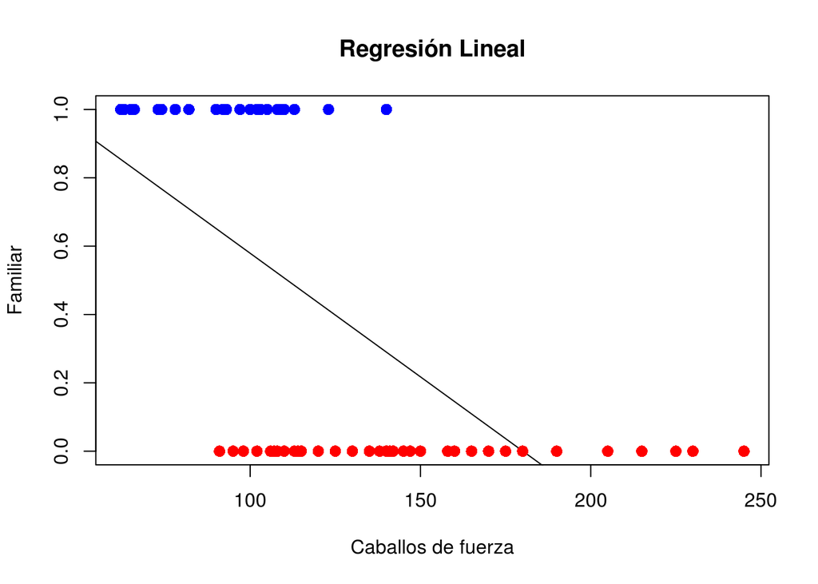

```r
colores <- ifelse(carros.dataset[, "Familiar"] == 1, "blue", "red") # Creamos los colores de los datos
plot(carros.dataset[, "CaballosFuerza"], carros.dataset[, "Familiar"], col = colores ,main = "Regresión Lineal", abline(modelo.lineal),cex = 1.3,pch = 16,xlab = "Caballos de fuerza",ylab = "Familiar")
```

## Predicción (usando modelo lineal)

Usamos el conjunto de pruebas y probamos el modelo. En la variable prediccion_lineal consta de 3 columnas, fit, lwr y upr. Utilizamos la columna fit que es el resultado de clasificar el conjunto de pruebas con el modelo.

```r
prediccion_lineal <-predict(modelo.lineal, conjunto_prueba, interval = "prediction")
prediccion_lineal
```

```
##            fit         lwr       upr
## 2   0.84671325  0.05860897 1.6348175
## 4   0.82501705  0.03843832 1.6115958
## 5   0.82501705  0.03843832 1.6115958
## 7   0.76716050 -0.01566669 1.5499877
## 8   0.73823222 -0.04289342 1.5193579
## 9   0.70930394 -0.07023735 1.4888452
## 13  0.64421532 -0.13219326 1.4206239
## 23  0.56466256 -0.20873810 1.3380632
## 32  0.50680601 -0.26497993 1.2785919
## 35  0.50680601 -0.26497993 1.2785919
## 36  0.50680601 -0.26497993 1.2785919
## 37  0.50680601 -0.26497993 1.2785919
## 38  0.50680601 -0.26497993 1.2785919
## 39  0.50680601 -0.26497993 1.2785919
## 43  0.48510980 -0.28619575 1.2564154
## 44  0.48510980 -0.28619575 1.2564154
## 45  0.47787773 -0.29328291 1.2490384
## 47  0.43448532 -0.33596580 1.2049364
## 48  0.41278911 -0.35741025 1.1829885
## 49  0.41278911 -0.35741025 1.1829885
## 51  0.36216463 -0.40771479 1.1320440
## 63  0.21752325 -0.55350666 0.9885532
## 67  0.21752325 -0.55350666 0.9885532
## 71  0.14520256 -0.62754612 0.9179512
## 82 -0.07175951 -0.85417165 0.7106526
## 84 -0.25256124 -1.04804289 0.5429204
## 85 -0.32488193 -1.12681802 0.4770542
```

## Matriz de confusión para las predicciones (lineal)

Una matriz de confusión es una herramienta que permite la visualización del desempeño de un algoritmo que se emplea en aprendizaje supervisado. Cada columna de la matriz representa el número de predicciones de cada clase, mientras que cada fila representa a las instancias en la clase real.

Convertimos a categoría el atributo “Familiar” del conjunto de prueba para poder compararlo con las predicciones

```r
factor_prueba <- as.factor(conjunto_prueba[, "Familiar"])
```

Se deben redondear las predicciones resultantes a el entero más cercano para poder compararlas con la clase verdadera. Podemos observar que se obtuvo una precisión 70% con el conjunto de pruebas.

```r
library(caret)
pred_lineal <- as.vector(prediccion_lineal[, "fit"])
pred_lineal <- as.factor(ifelse(pred_lineal > 0.5, 1, 0)) # Cambiamos valores a 1s y 0s

# Creamos las matriz de confusión
confusionMatrix(factor_prueba, pred_lineal)
```

```
## Confusion Matrix and Statistics
##
##           Reference
## Prediction  0  1
##          0 10  5
##          1  3  9
##
##                Accuracy : 0.7037
##                  95% CI : (0.4982, 0.8625)
##     No Information Rate : 0.5185
##     P-Value [Acc > NIR] : 0.04012
##
##                   Kappa : 0.4098
##  Mcnemar's Test P-Value : 0.72367
##
##             Sensitivity : 0.7692
##             Specificity : 0.6429
##          Pos Pred Value : 0.6667
##          Neg Pred Value : 0.7500
##              Prevalence : 0.4815
##          Detection Rate : 0.3704
##    Detection Prevalence : 0.5556
##       Balanced Accuracy : 0.7060
##
##        'Positive' Class : 0
##
```